# DACSS-603_Spring25:Homework 1

Author

Kuan-Cheng Lee

#library installation

```r
library(ggplot2)
library(dplyr)
```

# Question 1

First, let’s download the LungCap.csv file and save it to your Quarto project folder. Read in the data file.

```r
df <- read.csv("LungCapData.csv")
```

The distribution of LungCap looks as follows:

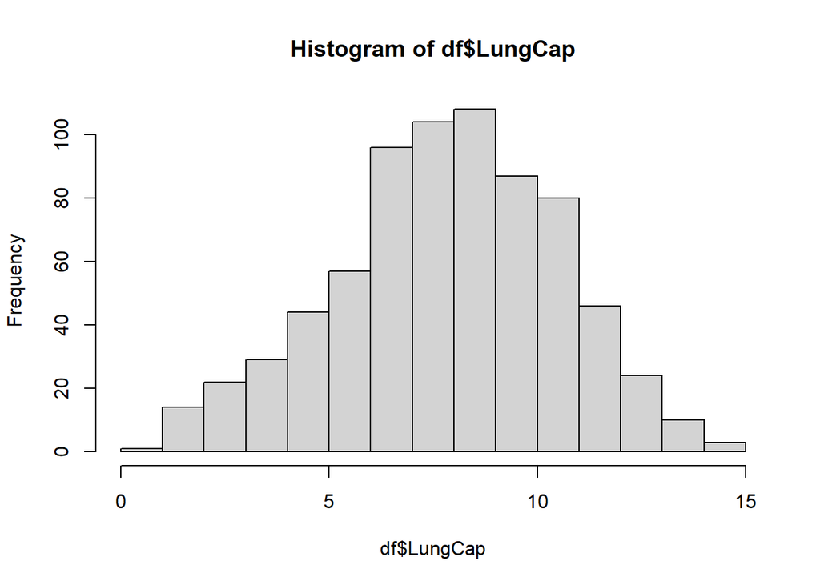

```r
hist(df$LungCap)
```

The histogram suggests that the distribution is close to a normal distribution. Most of the observations are close to the mean. Very few observations are close to the margins (0 and 15).

1. distribution of LungCup:

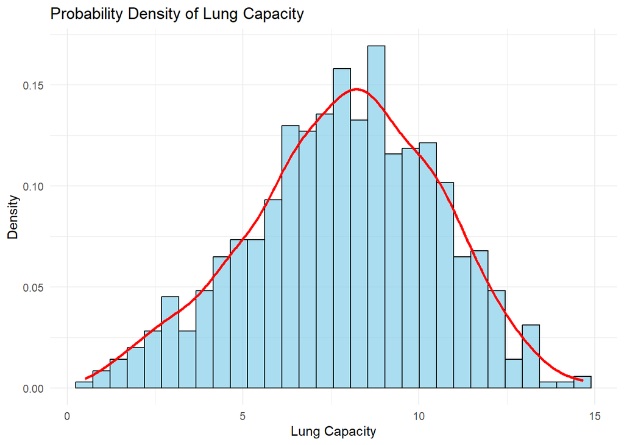

```r
ggplot(df, aes(x = LungCap)) +
  geom_histogram(aes(y = ..density..), bins = 30, fill = "skyblue", color = "black", alpha = 0.7) +
  geom_density(color = "red", linewidth = 1) +
  labs(title = "Probability Density of Lung Capacity", x = "Lung Capacity", y = "Density") +
  theme_minimal()
```

2. Comparing LungCap Distribution by Gender:

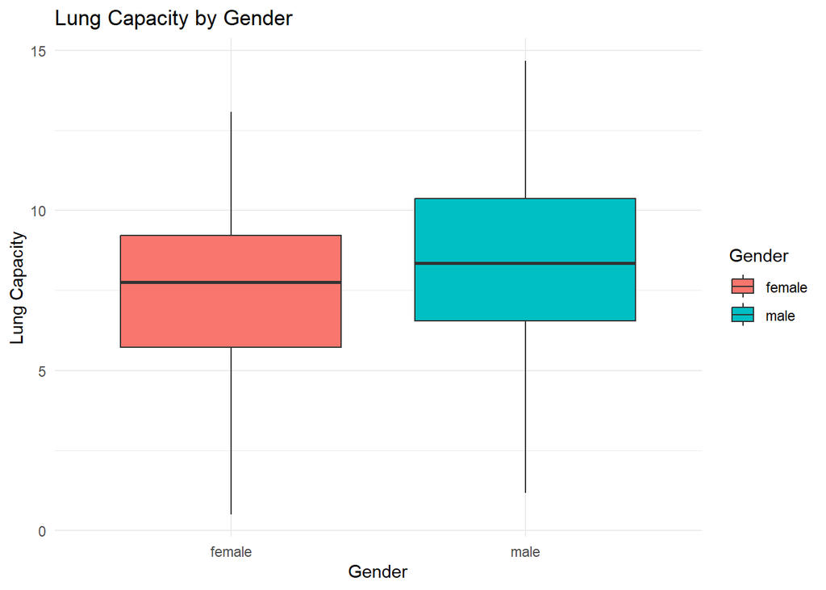

```r
ggplot(df, aes(x = Gender, y = LungCap, fill = Gender)) +
  geom_boxplot() +
  labs(title = "Lung Capacity by Gender", x = "Gender", y = "Lung Capacity") +
  theme_minimal()
```

3. Comparing Mean LungCap for Smokers vs. Non-Smokers:

```r
df %>%
  group_by(Smoke) %>%
  summarize(mean_LungCap = mean(LungCap, na.rm = TRUE),
            sd_LungCap = sd(LungCap, na.rm = TRUE),
            n = n())
```

```
# A tibble: 2 × 4
  Smoke mean_LungCap sd_LungCap     n
  <chr>        <dbl>      <dbl> <int>
1 no            7.77       2.73   648
2 yes           8.65       1.88    77
```

4. Relationship Between Smoking and Lung Capacity Across Age Groups:

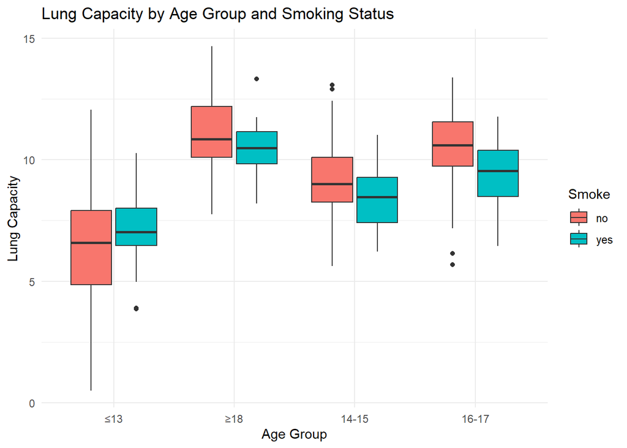

```r
df <- df %>%
  mutate(AgeGroup = case_when(
    Age <= 13 ~ "≤13",
    Age >= 14 & Age <= 15 ~ "14-15",
    Age >= 16 & Age <= 17 ~ "16-17",
    Age >= 18 ~ "≥18"
  ))
ggplot(df, aes(x = AgeGroup, y = LungCap, fill = Smoke)) +
  geom_boxplot() +
  labs(title = "Lung Capacity by Age Group and Smoking Status", x = "Age Group", y = "Lung Capacity") +
  theme_minimal()
```

5. Comparing LungCap for Smokers and Non-Smokers in Each Age Group:

```r
df %>%
  group_by(AgeGroup, Smoke) %>%
  summarize(mean_LungCap = mean(LungCap, na.rm = TRUE),
            sd_LungCap = sd(LungCap, na.rm = TRUE),
            n = n())
```

```
# A tibble: 8 × 5
# Groups:   AgeGroup [4]
  AgeGroup Smoke mean_LungCap sd_LungCap     n
  <chr>    <chr>        <dbl>      <dbl> <int>
1 14-15    no            9.14       1.55   105
2 14-15    yes           8.39       1.44    15
3 16-17    no           10.5        1.54    77
4 16-17    yes           9.38       1.33    20
5 ≤13      no            6.36       2.21   401
6 ≤13      yes           7.20       1.58    27
7 ≥18      no           11.1        1.56    65
8 ≥18      yes          10.5        1.25    15
```

# Question 2

Setting up the database

```r
total_prisoners <- 920
X <- c(0,1,2,3,4)
Frequency <- c(150, 420, 180, 100, 70)

prob <- Frequency/ total_prisoners

data <- data.frame(X, Frequency, prob)
print(data)
```

```
  X Frequency       prob
1 0       150 0.16304348
2 1       420 0.45652174
3 2       180 0.19565217
4 3       100 0.10869565
5 4        70 0.07608696
```

What is the probability that a randomly selected inmate has exactly 2 prior convictions? X = 2 **The answer is 0.1956522**

```r
p_2 <- prob[X == 2]
print(p_2)
```

```
[1] 0.1956522
```

What is the probability that a randomly selected inmate has fewer than 2 prior convictions? X < 2 **The answer is 0.6195652**

```r
p_less_than_2 <- sum(prob[X < 2])

print(p_less_than_2)
```

```
[1] 0.6195652
```

What is the probability that a randomly selected inmate has 2 or fewer than 2 prior convictions? X < = 2 **The answer is 0.8152174**

```r
p_less_than_or_equal_2 <- sum(prob[X <= 2]) #P(X = 0) + P(X = 1) + P(X = 2)
print(p_less_than_or_equal_2)
```

```
[1] 0.8152174
```

What is the probability that a randomly selected inmate has more than 2 prior convictions? X > 2 **The answer is 0.1847826**

```r
p_more_than_2 <- sum(prob[X > 2]) #P(X = 3) + P(X = 4)
print(p_more_than_2)
```

```
[1] 0.1847826
```

What is the expected value for the number of prior convictions? **The value is 1.478261**

```r
expected_value <- sum(X * prob)
print(expected_value)
```

```
[1] 1.478261
```

Calculte the variance and the standard deviation for the Prior Convictions. **The varience is 1.249527. The standard deviation is 1.117823.**

```r
E_X2 <- sum((X^2) * prob)
varience <- E_X2 - (expected_value^2)
std_dev <- sqrt(varience)

print(varience)
```

```
[1] 1.249527
```

```r
print(std_dev)
```

```
[1] 1.117823
```